# Italy's Textbook Market & Territorial School Access

### A Data-Driven Analysis of Cost Burden, Publisher Power & Geographic Opportunity Gaps

**Research questions**

| # | Question |
| --- | --- |
| 1 | How much do Italian families spend on textbooks per school level, and which track is most expensive? |
| 2 | How concentrated is the Italian textbook market — is it a captive oligopoly? |
| 3 | Which books are mandatory vs optional, and how many new adoption cycles lock out the used-book market? |
| 4 | How many secondary schools of each type exist in each territory, and what does this mean for aspiration? |
| 5 | How many Italian communes have no vocational school — forcing students to travel or abandon their path? |

**Data sources**  
MinIstruzione — LibriDiTesto adoption lists (17 regions, 2025 school year) · SCUANAGRAFESTAT school registry 2024–25  
MUR immatricolati by diploma type · ItalianMeanSecondarySchoolExpenses.csv · ItalyPrimarySchoolBookExpenses.csv

```
Setup complete.
  LibriDiTesto path: C:\Users\Dell\Documents\VSC Projects\Italienation\local_data\MinIstruzione\LibriDiTesto
  School registry:   C:\Users\Dell\Documents\VSC Projects\Italienation\local_data\MinIstruzione\Scuole
  Output:            C:\Users\Dell\Documents\VSC Projects\Italienation\Notebooks\neet_outputs
```

## 1 — Loading the Textbook Adoption Dataset

Every Italian school submits an annual *lista adozioni* (adoption list) to the Ministry of Education, listing every textbook adopted per class per year of study. This dataset captures that list for all 17 available regions in the 2025 school year.

> **3 million+ rows** — one row = one textbook adopted in one class section in one school.

```
Loading all regions...
Loaded: 3,085,602 rows | 26,664 schools | 29,770 unique ISBNs
        462 publishers | 17 regions | 99.9% rows have valid price
```

## 2 — The Cost Burden: Textbook Prices by School Level

How much does an Italian family pay for textbooks? The answer depends critically on which type of school their child attends. Technical-vocational schools have the highest per-book cost.

```
                       Avg €  Median €  Std €  Adoptions
GRADE_LABEL
Tecnico-Prof (Sec II)  30.44     30.90   9.67    1044874
Liceo/Ord (Sec II)     26.63     26.50   8.95     701748
Media (Sec I)          25.94     26.00   7.96     901925
Primaria               12.04      8.19   6.12     434583
```

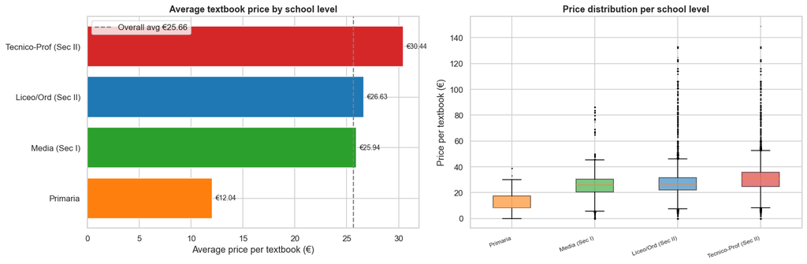

```
Estimated TOTAL annual textbook cost per family (unique books per school):
                       median    mean    q25     q75
GRADE_LABEL
Tecnico-Prof (Sec II)  1226.0  1585.0  854.0  2004.0
Media (Sec I)           762.0   915.0  698.0   856.0
Liceo/Ord (Sec II)      694.0   872.0  566.0  1013.0
Primaria                212.0   216.0  204.0   221.0
```

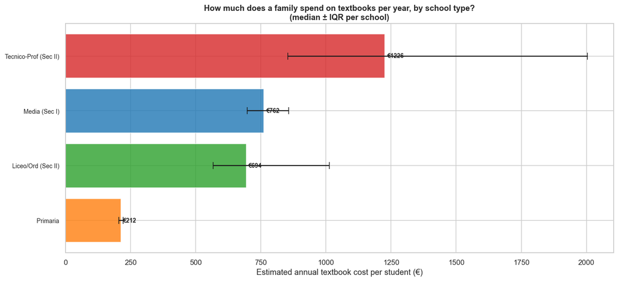

## 3 — Mandatory Purchases & New Adoptions: Lock-In Mechanisms

Two flags in the adoption list reveal structural cost drivers:

- **DAACQUIST = Si** → the book *must* be purchased (cannot be waived)
- **NUOVAADOZ = Si** → this is a *new* adoption — students cannot use a second-hand copy because the previous year's cohort used a different edition

New adoptions in particular **destroy the used-book market**: a family whose older child used the book cannot pass it down, as the school has switched to a new edition.

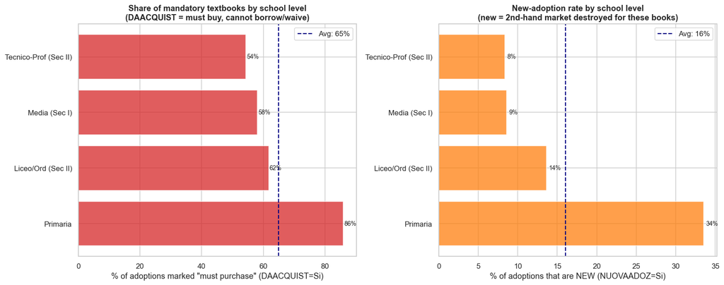

```
Summary:
  Books marked mandatory (DAACQUIST=Si): 61.5% of all adoptions
  Books as new adoptions (NUOVAADOZ=Si): 13.2% of all adoptions
```

## 4 — The Textbook Publisher Oligopoly

Publisher concentration (Herfindahl-Hirschman Index) tells us how concentrated power is:

- HHI < 1,500 → competitive
- HHI 1,500–2,500 → moderately concentrated
- HHI > 2,500 → highly concentrated

With 462 publishers but a single firm (Zanichelli) holding ~17% of all adoptions, the HHI for adoption-count concentration is worth computing.

```
HHI (all publishers, adoption count): 460
CR4 (top-4 concentration ratio): 29.0%
Top-5 publishers: 32.6% of all adoptions
Top-15 publishers: 59.0% of all adoptions
Total publishers: 462
```

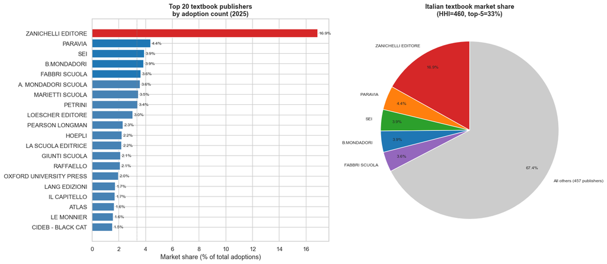

```
=== Liceo/Ord (Sec II) ===
           EDITORE  adoptions       pct
ZANICHELLI EDITORE     164746 23.455561
       B.MONDADORI      33022  4.701477
   MARIETTI SCUOLA      32636  4.646521
               SEI      32067  4.565510
  LOESCHER EDITORE      29358  4.179818

=== Media (Sec I) ===
            EDITORE  adoptions       pct
 ZANICHELLI EDITORE     108513 12.026613
      FABBRI SCUOLA      83665  9.272682
        B.MONDADORI      58034  6.431971
A. MONDADORI SCUOLA      44769  4.961797
                SEI      41723  4.624205

=== Primaria ===
        EDITORE  adoptions       pct
  GIUNTI SCUOLA      65231 14.995219
      RAFFAELLO      51794 11.906338
   IL CAPITELLO      31557  7.254283
PEARSON LONGMAN      28083  6.455684
       LA SPIGA      27459  6.312240

=== Tecnico-Prof (Sec II) ===
           EDITORE  adoptions       pct
ZANICHELLI EDITORE     247613 23.673706
           PARAVIA      85446  8.169294
               SEI      46229  4.419848
            HOEPLI      45763  4.375295
   MARIETTI SCUOLA      45377  4.338390

Zanichelli share in secondary (NO+NT):
  23.6%
```

## 5 — Which Subjects Cost the Most? Discipline-Level Price Analysis

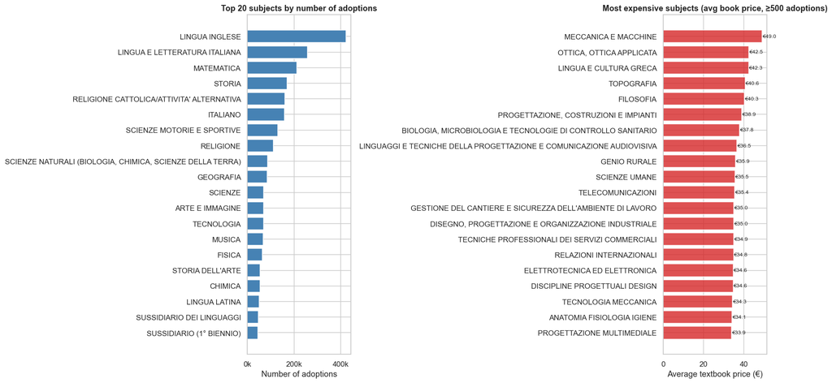

## 6 — Regional Price Variation: North–South Divide in Textbook Costs?

```
                      mean  median   count
REGIONE
Friuliveneziagiulia  28.60   28.40   60597
Marche               28.58   28.30   86537
Umbria               28.50   28.30   47643
Piemonte             28.40   28.25  200181
Basilicata           28.40   28.50   31649
Toscana              28.38   28.10  185731
Valledaosta          28.22   28.60    5663
Emiliaromagna        28.21   28.10  209107
Lombardia            28.18   28.30  454542
Veneto               28.13   28.00  230963
Lazio                28.06   28.10  285727
Liguria              28.01   27.90   65738
Puglia               27.72   27.70  221125
Molise               27.71   27.70   16632
Abruzzo              27.62   27.50   65988
Calabria             27.26   27.30  114837
Campania             26.50   26.80  365887
```

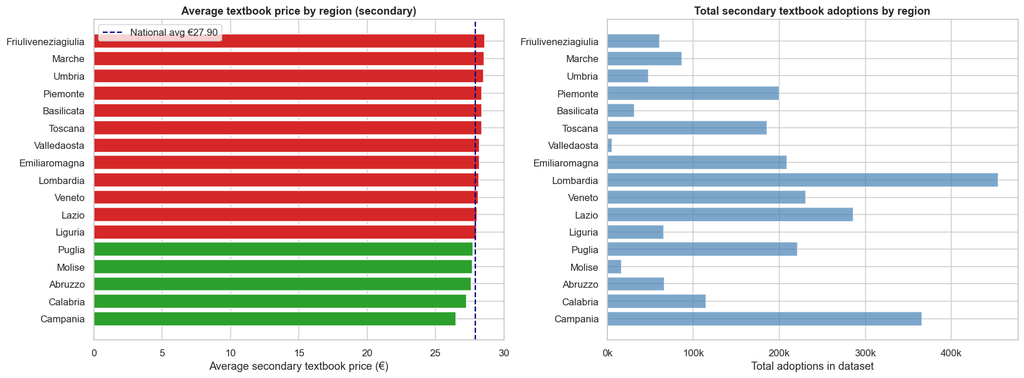

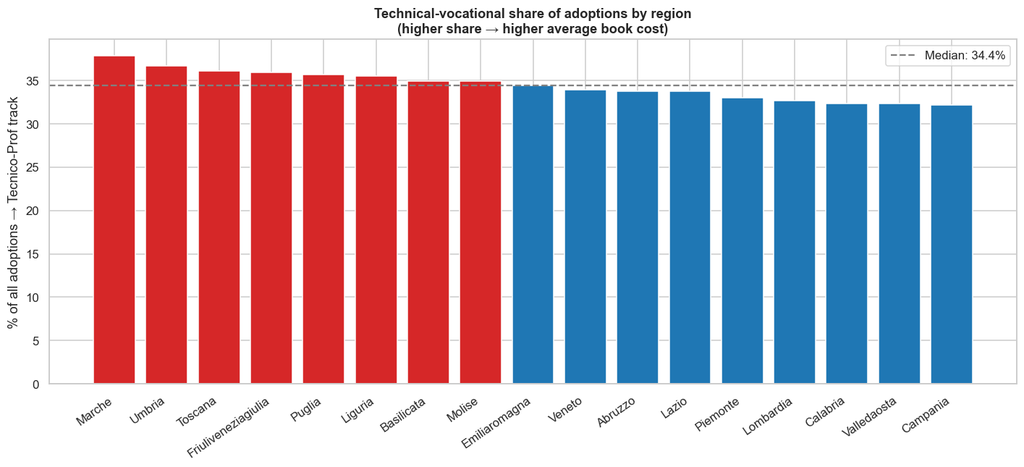

## 7 — Where Are the Schools? Territorial Access to Each Track

Italy's tripartite secondary system (Liceo / Istituto Tecnico / Istituto Professionale) assumes that **all three tracks are locally accessible**. But is this true?

If a student's commune has only a Liceo, they cannot enrol in Professionale without commuting — or they default to Liceo even if it does not match their interests or learning style. Conversely, if only Professionale schools exist nearby, academically ambitious students are pushed towards a path that statistically leads to lower university participation.

> **This is not a capability gap — it is a geography gap.**

```
Total secondary school branches in registry: 7,114

By track:
TRACK
Istituto Tecnico          2676
Liceo                     2220
Istituto Professionale    2218
Name: count, dtype: int64

By area:
TRACK           Istituto Professionale  Istituto Tecnico  Liceo
AREAGEOGRAFICA
CENTRO                             407               527    453
ISOLE                              368               405    340
NORD EST                           330               391    279
NORD OVEST                         406               568    433
SUD                                707               785    715
```

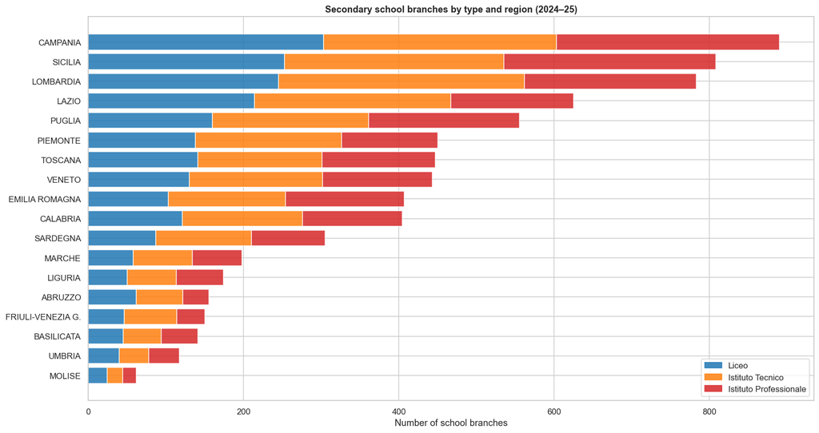

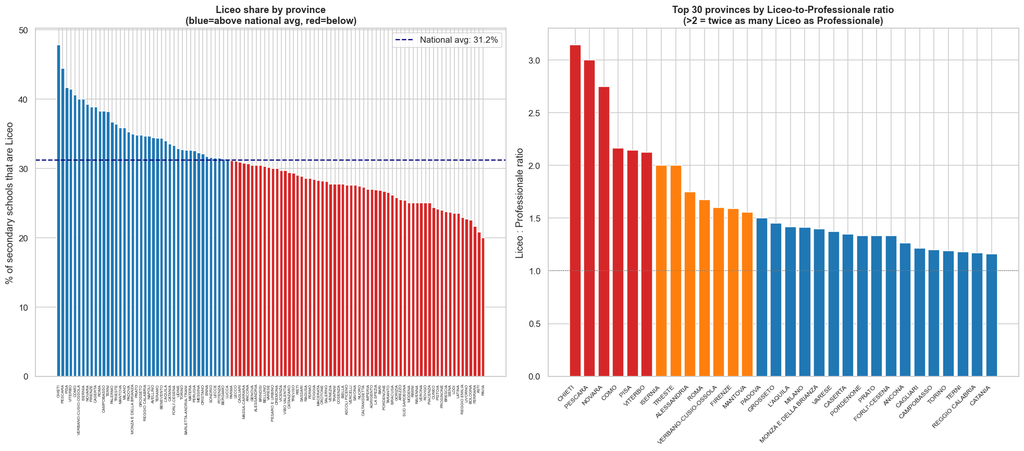

```
National Liceo:Professionale ratio: 1.00
National Liceo share: 31.2%
National Prof share: 31.2%
```

## 8 — The Comune-Level Access Gap: Forced Choices & Aspiration Barriers

School choice requires physical proximity. Italy has ~7,900 inhabited communes. The tripartite system only functions fairly if all three track types are accessible in your area.

**If your commune has only a Liceo** → vocational-minded students must commute or conform.  
**If your commune has only a Professionale** → academically ambitious students are pre-sorted away from H.E.

This section quantifies how many communes have each type of school — and how many have *none*.

```
Total communes in registry:                 6,664
Communes with ANY secondary school:         1,433  (21.5%)
  ├ With at least 1 Liceo:                  1,025  (15.4%)
  ├ With at least 1 Istituto Tecnico:         978  (14.7%)
  └ With at least 1 Istituto Professionale:   923  (13.9%)
Communes with NO secondary school:          5,231  (78.5%)
```

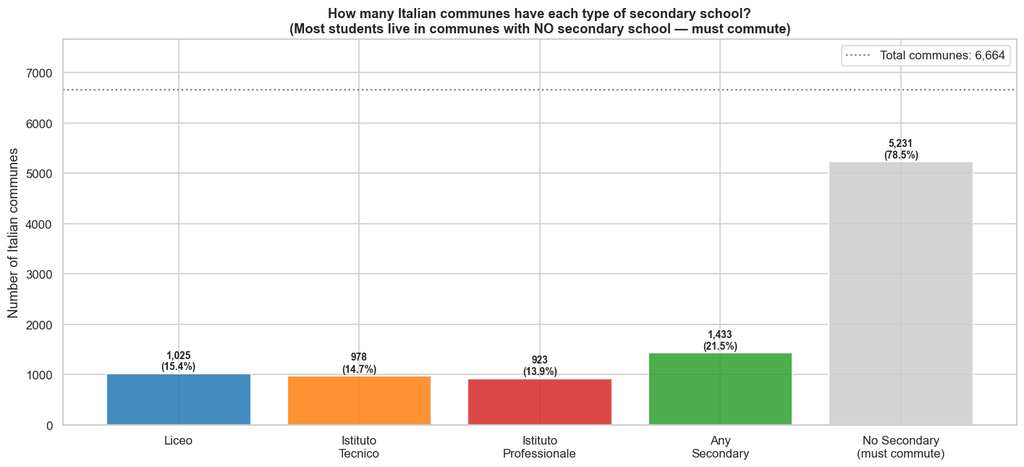

```
Communes with ONLY a Liceo (forced academic path): 178
Communes with ONLY a Professionale (forced vocational): 164
Communes with ONLY a Tecnico: 147
Communes with ALL THREE tracks: 549
```

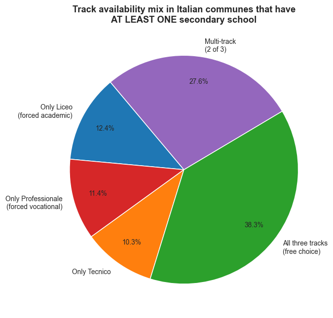

## 9 — Structural Imbalance: Which Regions Force Students Into Pre-Defined Paths?

When Liceo schools dominate a region, students who would prefer vocational education face longer commutes or abandon their preferred trajectory. When Professionale schools dominate, academically motivated students from less affluent backgrounds may not consider Liceo as an option — not from choice, but from geography.

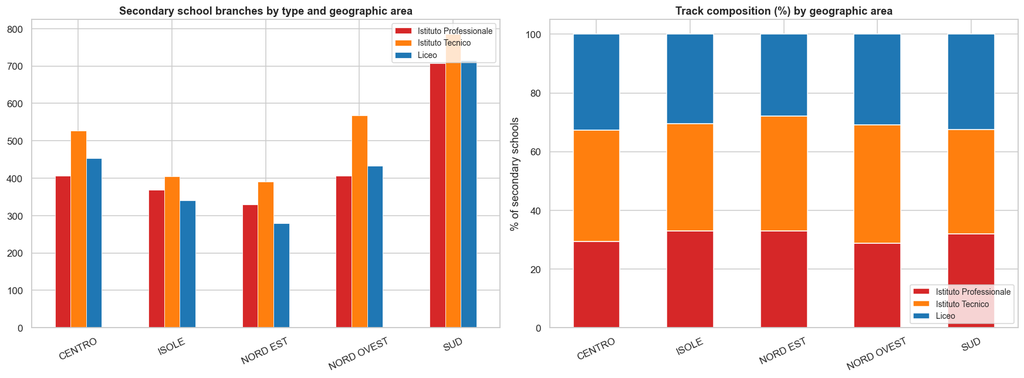

```
TRACK           Istituto Professionale  Istituto Tecnico  Liceo
AREAGEOGRAFICA
CENTRO                            29.3              38.0   32.7
ISOLE                             33.1              36.4   30.5
NORD EST                          33.0              39.1   27.9
NORD OVEST                        28.9              40.4   30.8
SUD                               32.0              35.6   32.4
```

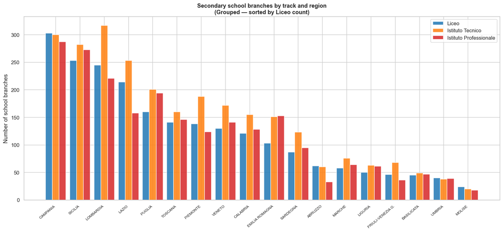

## 10 — Synthesis: Two Barriers Reinforcing Each Other

Italy's educational system confronts families with a double burden:

### A — The Cost Barrier (Textbooks)

| Level | Avg book price | Est. annual family spend |
| --- | --- | --- |
| Primaria (Elem) | €12 | ~€216 |
| Media (Sec I) | €26 | ~€915 |
| Liceo (Sec II) | €27 | ~€872 |
| Tecnico-Prof (Sec II) | €30 | ~€1,585 |

### The Compound Effect

A student from a low-income family in a Liceo-dominant province who:

1. Cannot afford annual textbook costs (€900–1,600)
2. Cannot choose their preferred school type without travelling
3. Performs poorly in an inappropriate school type

...is structurally predisposed to becoming **NEET** — not through lack of ability, but through accumulated structural disadvantage.

> **Constitutional argument**: Art. 34 of the Italian Constitution states that capable and deserving students, *even those without means*, have the right to reach the highest levels of education. The combination of textbook costs and territorial school access gaps directly violates this constitutional guarantee for hundreds of thousands of Italian youth.

```
{
  "notebook": "italy_textbooks_schools_territory.ipynb",
  "generated": "2026-04-12T17:27:58.948889",
  "data": {
    "total_book_adoptions": 3085602,
    "unique_ISBNs": 29770,
    "unique_schools_in_adoption_data": 26664,
    "unique_publishers": 462,
    "regions_covered": 17,
    "avg_book_price_eur": 25.66,
    "pct_mandatory": 61.5,
    "pct_new_adoption": 13.2
  },
  "schools": {
    "total_secondary_branches": 7114,
    "communes_with_any_secondary": 1433,
    "communes_with_liceo": 1025,
    "communes_with_professionale": 923,
    "communes_with_no_secondary": 5231
  },
  "figures": [
    "lb_01_price_by_grade.png",
    "lb_02_total_annual_cost.png",
    "lb_03_mandatory_new_adoptions.png",
    "lb_04_publisher_concentration.png",
    "lb_05_discipline_prices.png",
    "lb_06_regional_prices.png",
    "lb_07_tech_share_by_region.png",
    "lb_08_schools_by_track_region.png",
    "lb_09_liceo_prof_ratio_by_province.png",
    "lb_10_commune_access.png",
    "lb_11_commune_track_mix.png",
    "lb_12_area_track_composition.png",
    "lb_13_region_track_grouped.png"
  ]
}
```

## Additional: Books per subject & Schools per book

This section computes:

- Unique textbook count per discipline (unique ISBNs per subject).
- Number of schools adopting each ISBN, distribution and top lists.
- Scatter: average price vs number of schools adopting each ISBN.

```
Unique ISBNs per discipline (top 30):
DISCIPLINA
LINGUA E LETTERATURA ITALIANA                                3112
LINGUA INGLESE                                               3046
STORIA                                                       2119
ITALIANO                                                     2089
MATEMATICA                                                   1784
SCIENZE NATURALI (BIOLOGIA, CHIMICA, SCIENZE DELLA TERRA)     974
LINGUA LATINA                                                 906
GEOGRAFIA                                                     845
LINGUA E CULTURA STRANIERA (FRANCESE)                         768
RELIGIONE CATTOLICA/ATTIVITA' ALTERNATIVA                     730
STORIA DELL'ARTE                                              664
CHIMICA                                                       589
SCIENZE                                                       548
FISICA                                                        519
FILOSOFIA                                                     505
LINGUA E CULTURA STRANIERA (SPAGNOLO)                         492
SECONDA LINGUA COMUNITARIA (FRANCESE)                         442
ARTE E IMMAGINE                                               413
MUSICA                                                        404
LINGUA E CULTURA GRECA                                        391
INFORMATICA                                                   390
LINGUA E CULTURA STRANIERA (TEDESCO)                          387
DIRITTO ED ECONOMIA                                           375
TECNOLOGIA                                                    362
DISEGNO                                                       320
SCIENZE MOTORIE E SPORTIVE                                    316
STORIA E GEOGRAFIA                                            254
DIRITTO                                                       251
SECONDA LINGUA COMUNITARIA (SPAGNOLO)                         240
PARASCOLASTICA (AMBITO UMANISTICO)                            228
```

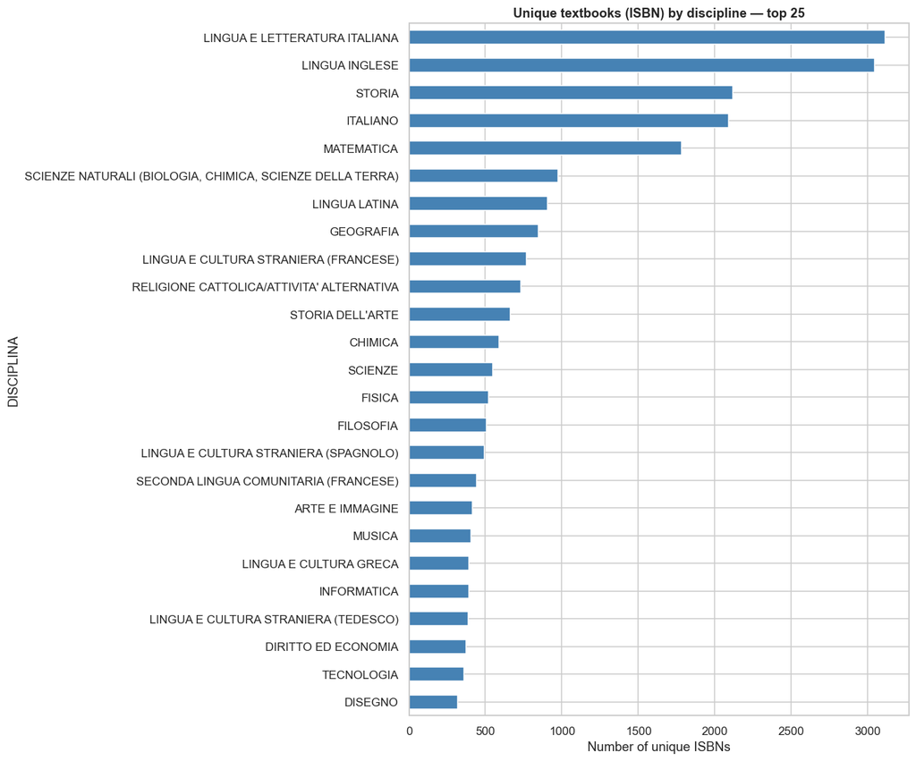

```
Schools per ISBN — descriptive:
count    29770.0
mean        32.1
std        106.3
min          1.0
25%          1.0
50%          4.0
75%         22.0
max       4290.0
Name: n_schools, dtype: float64

Top 20 most widely adopted ISBNs (by number of unique schools):
               n_schools                                           TITOLO              EDITORE  PREZZO_AVG                 DISCIPLINA
CODICEISBN
9788809930087       4290                      UN CIELO A COLORI CL. 1-2-3        GIUNTI SCUOLA        8.19                  RELIGIONE
9788809930094       3727                        UN CIELO A COLORI CL. 4-5        GIUNTI SCUOLA        8.19                  RELIGIONE
9788847242449       3014                      FIORI DELLA TERRA 1-2-3 (I)            RAFFAELLO        8.19                  RELIGIONE
9788847242456       2619                        FIORI DELLA TERRA 4-5 (I)            RAFFAELLO        8.19                  RELIGIONE
9788842632931       2300    NUOVO COME FARFALLE DAI MILLE COLORI 4-5 (IL)         IL CAPITELLO        8.19                  RELIGIONE
9788847242463       2206                                    HELLO WORLD 1    CELTIC PUBLISHING        4.02             LINGUA INGLESE
9788847242470       2153                                    HELLO WORLD 2    CELTIC PUBLISHING        6.03             LINGUA INGLESE
9788842632924       1968  NUOVO COME FARFALLE DAI MILLE COLORI 1-2-3 (IL)         IL CAPITELLO        8.19                  RELIGIONE
9788883397097       1899                                 BILLY BOT GOLD 3      PEARSON LONGMAN        8.06             LINGUA INGLESE
9788847242364       1855                                    VERDE PRATO 2            RAFFAELLO       18.69   SUSSIDIARIO (1° BIENNIO)
9788883397110       1845                                 BILLY BOT GOLD 5      PEARSON LONGMAN       10.08             LINGUA INGLESE
9788809964716       1828                                I LIKE GOLD CL. 4           GIUNTI ELT        8.06             LINGUA INGLESE
9788842632511       1806             COME FARFALLE DAI MILLE COLORI 1-2-3         IL CAPITELLO        8.19                  RELIGIONE
9788809964709       1711                                I LIKE GOLD CL. 3           GIUNTI ELT        8.06             LINGUA INGLESE
9788809964723       1696                                I LIKE GOLD CL. 5           GIUNTI ELT       10.08             LINGUA INGLESE
9788883397103       1691                                 BILLY BOT GOLD 4      PEARSON LONGMAN        8.06             LINGUA INGLESE
9788809917606       1690                         NUOVO VIVA LEGGERE CL. 5        GIUNTI SCUOLA       20.96  SUSSIDIARIO DEI LINGUAGGI
9791220410731       1675                        BOTTEGA DELLE STORIE (LA)  A. MONDADORI SCUOLA       17.28  SUSSIDIARIO DEI LINGUAGGI
9788809929999       1664                            MILLE AVVENTURE CL. 3        GIUNTI SCUOLA       26.71   SUSSIDIARIO (1° BIENNIO)
9788851910372       1635                             VALLE DEL CEDRO (LA)        PIEMME SCUOLA        8.19                  RELIGIONE
```

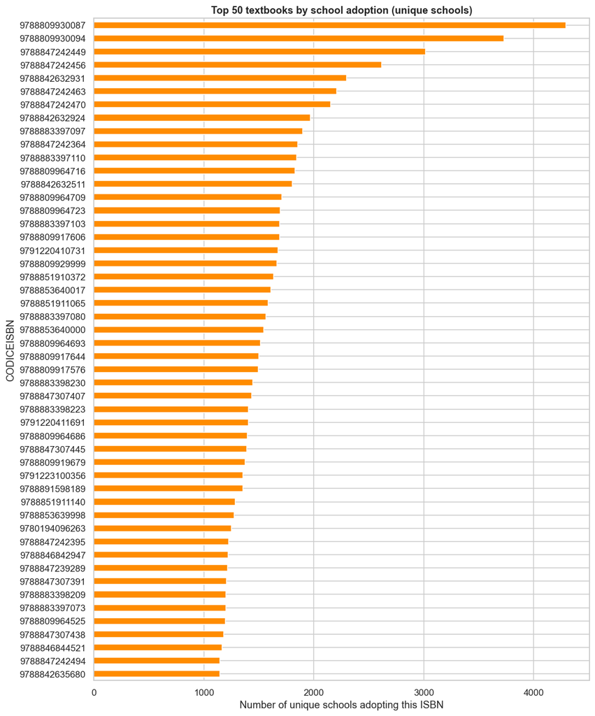

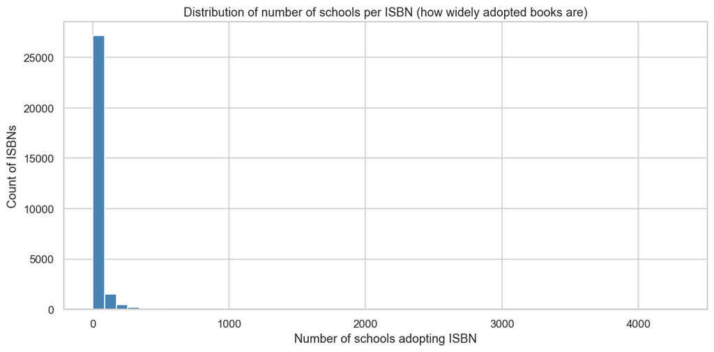

```
Correlation between schools adopting and avg price:
           n_schools  avg_price
n_schools      1.000      0.042
avg_price      0.042      1.000
```

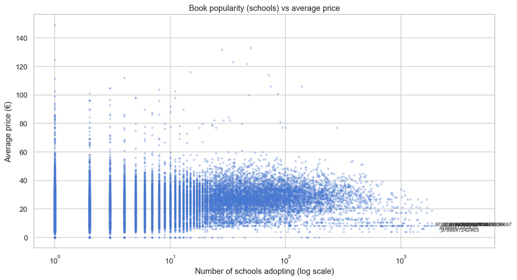

```
Saved figures: lb_14..lb_17 in neet_outputs/
```